# IODS course project

## Multiple Correspondence Analysis (MCA)

```r
# Load the dataset
library(FactoMineR)
library(dplyr); library(ggplot2); library(tidyr)
data(tea)
glimpse(tea)
```

```
## Observations: 300
## Variables: 36
## $ breakfast        <fct> breakfast, breakfast, Not.breakfast, Not.brea...
## $ tea.time         <fct> Not.tea time, Not.tea time, tea time, Not.tea...
## $ evening          <fct> Not.evening, Not.evening, evening, Not.evenin...
## $ lunch            <fct> Not.lunch, Not.lunch, Not.lunch, Not.lunch, N...
## $ dinner           <fct> Not.dinner, Not.dinner, dinner, dinner, Not.d...
## $ always           <fct> Not.always, Not.always, Not.always, Not.alway...
## $ home             <fct> home, home, home, home, home, home, home, hom...
## $ work             <fct> Not.work, Not.work, work, Not.work, Not.work,...
## $ tearoom          <fct> Not.tearoom, Not.tearoom, Not.tearoom, Not.te...
## $ friends          <fct> Not.friends, Not.friends, friends, Not.friend...
## $ resto            <fct> Not.resto, Not.resto, resto, Not.resto, Not.r...
## $ pub              <fct> Not.pub, Not.pub, Not.pub, Not.pub, Not.pub, ...
## $ Tea              <fct> black, black, Earl Grey, Earl Grey, Earl Grey...
```

[output cut: 23 more lines]

```r
str(tea)
```

```
## 'data.frame':    300 obs. of  36 variables:
##  $ breakfast       : Factor w/ 2 levels "breakfast","Not.breakfast": 1 1 2 2 1 2 1 2 1 1 ...
##  $ tea.time        : Factor w/ 2 levels "Not.tea time",..: 1 1 2 1 1 1 2 2 2 1 ...
##  $ evening         : Factor w/ 2 levels "evening","Not.evening": 2 2 1 2 1 2 2 1 2 1 ...
##  $ lunch           : Factor w/ 2 levels "lunch","Not.lunch": 2 2 2 2 2 2 2 2 2 2 ...
##  $ dinner          : Factor w/ 2 levels "dinner","Not.dinner": 2 2 1 1 2 1 2 2 2 2 ...
##  $ always          : Factor w/ 2 levels "always","Not.always": 2 2 2 2 1 2 2 2 2 2 ...
##  $ home            : Factor w/ 2 levels "home","Not.home": 1 1 1 1 1 1 1 1 1 1 ...
##  $ work            : Factor w/ 2 levels "Not.work","work": 1 1 2 1 1 1 1 1 1 1 ...
##  $ tearoom         : Factor w/ 2 levels "Not.tearoom",..: 1 1 1 1 1 1 1 1 1 2 ...
##  $ friends         : Factor w/ 2 levels "friends","Not.friends": 2 2 1 2 2 2 1 2 2 2 ...
##  $ resto           : Factor w/ 2 levels "Not.resto","resto": 1 1 2 1 1 1 1 1 1 1 ...
##  $ pub             : Factor w/ 2 levels "Not.pub","pub": 1 1 1 1 1 1 1 1 1 1 ...
##  $ Tea             : Factor w/ 3 levels "black","Earl Grey",..: 1 1 2 2 2 2 2 1 2 1 ...
##  $ How             : Factor w/ 4 levels "alone","lemon",..: 1 3 1 1 1 1 1 3 3 1 ...
```

[output cut: 22 more lines]

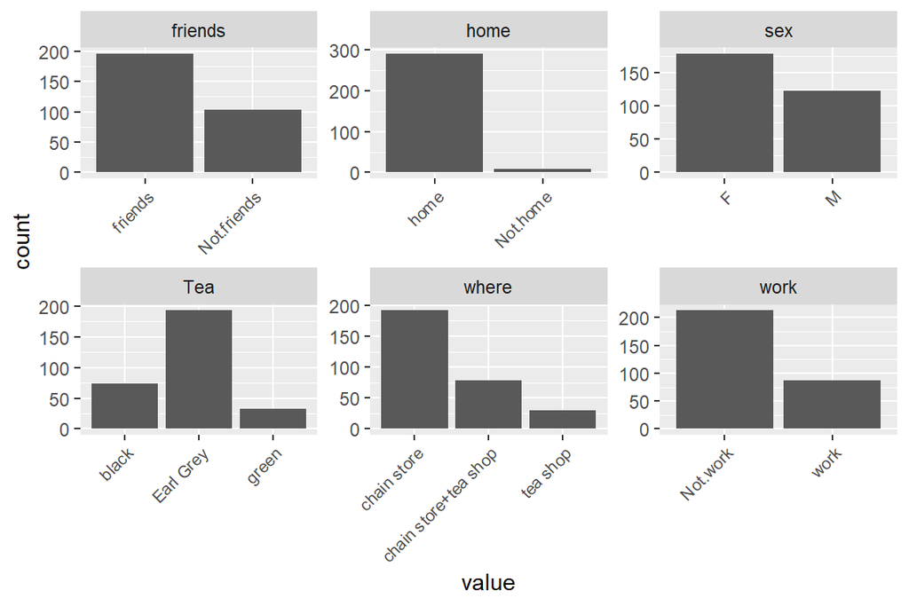

```r
# There are 36 variables, so, let's take just six interesting ones
tea_time = tea[, c("Tea", "where", "sex", "home", "work", "friends")]

# visualize the dataset
gather(tea_time) %>% ggplot(aes(value)) + facet_wrap("key", scales = "free") + geom_bar() + theme(axis.text.x = element_text(angle = 45, hjust = 1, size = 8))
```

**Interpretation:** The FactoMineR package is described here https://cran.r-project.org/web/packages/FactoMineR/FactoMineR.pdf, but there was no metadata for the ‘tea’ data. The first 18 questions are about how the respondents drink tea. So, I assume the variables describe, whether the person drinks tea with his/her friends, at home, at work, which tea, where the tea is bought, and the respondents sex.

```r
# Let's conduct the MCA
mca <- MCA(tea_time, graph = FALSE)
summary(mca)
```

```
##
## Call:
## MCA(X = tea_time, graph = FALSE)
##
##
## Eigenvalues
##                        Dim.1   Dim.2   Dim.3   Dim.4   Dim.5   Dim.6
## Variance               0.257   0.196   0.181   0.172   0.144   0.133
## % of var.             19.268  14.737  13.555  12.868  10.831   9.966
## Cumulative % of var.  19.268  34.005  47.560  60.428  71.259  81.225
##                        Dim.7   Dim.8
## Variance               0.129   0.121
## % of var.              9.689   9.086
## Cumulative % of var.  90.914 100.000
##
## Individuals (the 10 first)
##                         Dim.1    ctr   cos2    Dim.2    ctr   cos2
## 1                    |  0.760  0.749  0.468 | -0.046  0.004  0.002 |
## 2                    |  0.454  0.267  0.186 | -0.064  0.007  0.004 |
## 3                    | -0.615  0.490  0.471 |  0.255  0.111  0.081 |
## 4                    |  0.471  0.287  0.271 |  0.337  0.193  0.139 |
## 5                    |  0.471  0.287  0.271 |  0.337  0.193  0.139 |
## 6                    |  0.471  0.287  0.271 |  0.337  0.193  0.139 |
## 7                    |  0.085  0.009  0.012 |  0.138  0.032  0.032 |
## 8                    |  0.454  0.267  0.186 | -0.064  0.007  0.004 |
## 9                    |  0.126  0.021  0.013 | -0.140  0.033  0.016 |
## 10                   |  0.415  0.224  0.107 | -0.524  0.465  0.170 |
##                       Dim.3    ctr   cos2
## 1                    -0.621  0.712  0.313 |
## 2                    -0.789  1.148  0.564 |
## 3                     0.046  0.004  0.003 |
## 4                    -0.241  0.107  0.071 |
## 5                    -0.241  0.107  0.071 |
## 6                    -0.241  0.107  0.071 |
## 7                     0.062  0.007  0.007 |
## 8                    -0.789  1.148  0.564 |
## 9                    -0.083  0.013  0.006 |
## 10                   -0.463  0.395  0.133 |
##
## Categories (the 10 first)
```

[output cut: 16 more lines]

```
## chain store+tea shop   0.245  -8.558 |   0.055   0.073   0.001   0.566 |
## tea shop               0.041  -3.510 |   2.092  40.350   0.486  12.057 |
## F                      0.001  -0.391 |  -0.174   1.652   0.044  -3.629 |
## M                      0.001   0.391 |   0.254   2.410   0.044   3.629 |
## home                   0.551 -12.836 |  -0.039   0.134   0.049  -3.810 |
## Not.home               0.551  12.836 |   1.253   4.342   0.049   3.810 |
##
## Categorical variables (eta2)
##                        Dim.1 Dim.2 Dim.3
## Tea                  | 0.395 0.199 0.309 |
## where                | 0.331 0.339 0.516 |
## sex                  | 0.209 0.001 0.044 |
## home                 | 0.001 0.551 0.049 |
## work                 | 0.295 0.026 0.031 |
## friends              | 0.311 0.063 0.136 |
```

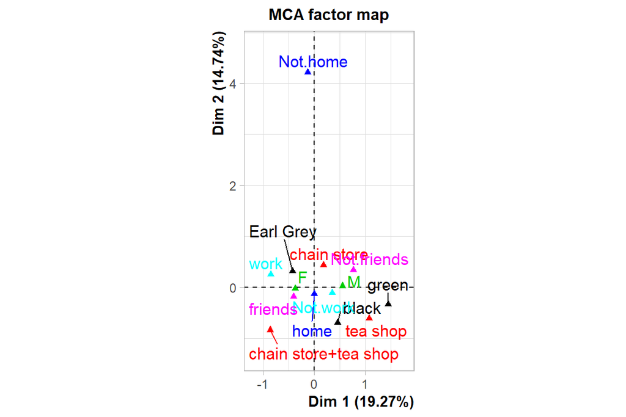

```r
# visualize MCA
plot(mca, invisible=c("ind"), habillage = "quali")
```

**Interpretation:** Drinking tea not at home is very far from the other measures used in this analysis.